# Lecture 2.1 Data Object Type and Structure

SIPA U6614 | Instructor: Harold Stolper

# 1 Introduction

Load packages:

```r
library(tidyverse)
```

Resources used to create this lecture:

- https://ozanj.github.io/rclass/lectures/lecture1/lecture1.2.pdf
- https://mgimond.github.io/ES218/Week02a.html
- https://cran.r-project.org/doc/manuals/r-release/R-lang.html#Objects

# 2 Data types in R

## 2.1 Core data types

Objects can be categorized by **type** and by **class**. For example:

- a date is an object with a numeric type and a date class
- a dataframe is an object with its own type and class

**Functions** in R do different things to objects depending on their type and/or class. For example:

- date functions process objects with *type = numeric* and *class = date*; these functions don’t work on objects with *type = character*
- the `typeof()` function works with any object

In this lecture we’ll use some basic functions, such as `typeof()`, that are part of the base R package (i.e. *base R syntax* that doesn’t require loading additional packages).

## 2.2 Vectors

The fundamental object in R is the “vector”. A vector is a collection of values of a particular type. Individual values within a vector are called “elements.”

Element values in a vector can be **numeric**, **character** (e.g. “whoa”), or **logical** (TRUE/FALSE). Common numeric data types include the `integer` and `double`.

The elements in a vector must be of the same type (e.g. all integers). We thus say that vectors are **homogeneous**.

We can create vectors using the combine function `c()`.

- Remember you can try running `?c` for help to see that `c()` “combines values into a vector or list.”

### A vector with numeric elements

```r
years <- c(2015, 2016, 2017, 2018, 2019, 2020) # create object called years as a vector with 3 integer elements
years # print object x
```

```
## [1] 2015 2016 2017 2018 2019 2020
```

```r
typeof(years)
```

```
## [1] "double"
```

#### A number is just a vector with 1 element!

```r
x <- 13
typeof(x)
```

```
## [1] "double"
```

```r
y <- c(13)
typeof(y)
```

```
## [1] "double"
```

### A vector with character elements

```r
shades <- c("light pink", "hot pink", "deep pink")
shades
```

```
## [1] "light pink" "hot pink"   "deep pink"
```

```r
typeof(shades)
```

```
## [1] "character"
```

### A vector with logical elements

Logical values (TRUE/FALSE) can be used to store binary information.

```r
v2 <- c(TRUE, TRUE, FALSE)
v2
```

```
## [1]  TRUE  TRUE FALSE
```

```r
typeof(v2)
```

```
## [1] "logical"
```

Now is a good time to point out that the keyboard shortcut to insert the assignment operator `<-` is **Alt+-** and **Option+-** for Windows and Mac, respectively.

# 3 Object class and factors

Objects can have additional attributes that tell them to be treated in particular ways by certain functions. The **class** of an object can store a set of attributes.

One commonly used class is the **factor**. Telling R that an object should be a factor is how we tell it that we’re working with a categorical variable. This enables certain functions to incorporate categorical information and utilize these discrete categories.

These categories are stored in another object attribute known as **levels**.

```r
gender <- c("F", "M", "F", "NB", "O")
typeof(gender)
```

```
## [1] "character"
```

```r
gender.fact <- as.factor(gender)
typeof(gender.fact)
```

```
## [1] "integer"
```

Note that factors are often displayed as characters, but they are stored internally as integers. The information R needs to do this is stored as attributes.

```r
gender
```

```
## [1] "F"  "M"  "F"  "NB" "O"
```

```r
gender.fact
```

```
## [1] F  M  F  NB O
## Levels: F M NB O
```

```r
attributes(gender.fact)
```

```
## $levels
## [1] "F"  "M"  "NB" "O"
##
## $class
## [1] "factor"
```

```r
levels(gender.fact)
```

```
## [1] "F"  "M"  "NB" "O"
```

Also notice that the object names we used, e.g. `gender.fact` give us a clue about what the object means and how we want to treat it in R.

It’s good practice to give your objects meaningful names that make it easier to follow and organize your code.

# 4 Data structures

The datasets we’ll be working with include batches of values. These batches of values are stored in R with a particular *data structure*. A vector is one kind of data structure, as are data frames, matrices and lists.

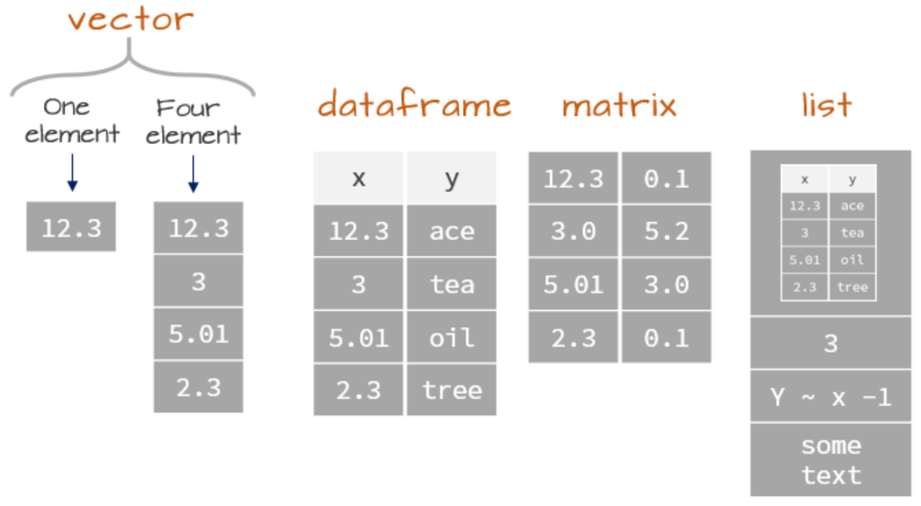

(Source: https://mgimond.github.io/ES218/Week02a.html#data_structures)

## 4.1 (Atomic) Vectors

An atomic vector (vector for short), like the ones we’ve just seen, is just an ordered list of elements of the same data type.

```r
quakes <- c(1565, 1696, 1566, 1808, 1637)
quakes
```

```
## [1] 1565 1696 1566 1808 1637
```

The ordering just means each element is indexed by a given number (think of subscripts on variables denoting observation *i*). This allows us to easily access a given element or subset of elements.

```r
quakes[1]
```

```
## [1] 1565
```

```r
quakes[2:4] # Note that the : operator give us a sequence
```

```
## [1] 1696 1566 1808
```

```r
quakes[c(2,3)] # Here we're using a vector to identify elements of a larger vector
```

```
## [1] 1696 1566
```

We can also assign new values to a particular element, by overwriting an existing value or adding an element.

```r
quakes[6] <- NA # Here we're adding a sixth element with the value NA
quakes
```

```
## [1] 1565 1696 1566 1808 1637   NA
```

Remember that vectors are **homogeneous**. So if you accidentally try to assign values with different data types to elements of the same vector, R will force each element into a single data type.

```r
v4 <- c(4, "six", TRUE)
v4
```

```
## [1] "4"    "six"  "TRUE"
```

```r
typeof(v4)
```

```
## [1] "character"
```

## 4.2 Matrices and arrays

A matrix works similarly to a vector, but is 2-dimensional. This means it has two ordered indices to indicate the row and column position. Matrices are also homogeneous – all elements must be of the same data type.

Arrays work similarly but can be n-dimensional, not just limited to rows and columns.

There are lots of ways to create matrices. Here is one approach that combines two vectors using the `cbind` function to generate a matrix with each vectors as its own column.

```r
m <- cbind(years, quakes)
m
```

```
##      years quakes
## [1,]  2015   1565
## [2,]  2016   1696
## [3,]  2017   1566
## [4,]  2018   1808
## [5,]  2019   1637
## [6,]  2020     NA
```

```r
typeof(m)
```

```
## [1] "double"
```

```r
m[3,2]
```

```
## quakes
##   1566
```

Note that if we try to incorporate another character vector, R will force all elements of the new vector into characters.

```r
magnitude <- c("5+", "5+", "5+", "5+", "5+", "5+")
m2 <- cbind(m, magnitude)
m2
```

```
##      years  quakes magnitude
## [1,] "2015" "1565" "5+"
## [2,] "2016" "1696" "5+"
## [3,] "2017" "1566" "5+"
## [4,] "2018" "1808" "5+"
## [5,] "2019" "1637" "5+"
## [6,] "2020" NA     "5+"
```

```r
typeof(m2)
```

```
## [1] "character"
```

## 4.3 Data frames

A data frame is in line with our notion of a dataset (especially as we think of it in Stata). It functions like a matrix but allows for columns with different data types.

The term *variable* can be used in different ways in R, but for present purposes we’re going to continue referring to variables as columns of data of a certain data type (i.e. a vector), with each element representing the value for an observation drawn from some population.

Let’s use the `data.frame` function to make a data frame with three columns for the vectors we defined for years, earthquakes, and magnitude, respectively.

```r
quakes.df <- data.frame(years, quakes, magnitude)
quakes.df
```

```
## # A tibble: 6 x 3
##   years quakes magnitude
##   <dbl>  <dbl> <chr>
## 1  2015   1565 5+
## 2  2016   1696 5+
## 3  2017   1566 5+
## 4  2018   1808 5+
## 5  2019   1637 5+
## 6  2020     NA 5+
```

This data.frame looks good – similar to our matrix of earthquake information based on the same vectors (`m2`), but with a nicer print display that shows the number of rows and columns, and an index number for each observation. The data frame also lists the data type for each column underneath the column name. Most importantly, notice that unlike with our matrix, a data frame can include columns with different data types – data frames can be **heterogenous**.

Wait a minute, that looks good but what’s a **tibble**?

A tibble is “a modern re-imagining of the data.frame” which will make our lives a bit easier at times. They are an foundational tool of the **tidyverse** package that we’ll talk about more soon.

Another convenient function that you should get used to using to explore your data is `str()`. According to the documentation provided by `?str`, this function will “compactly display the structure of an arbitrary R object.”

```r
str(quakes.df)
```

```
## 'data.frame':    6 obs. of  3 variables:
##  $ years    : num  2015 2016 2017 2018 2019 ...
##  $ quakes   : num  1565 1696 1566 1808 1637 ...
##  $ magnitude: chr  "5+" "5+" "5+" "5+" ...
```

We can access a subset of cells from the data frame by referring to the appropriate index values, just like with a vector or matrix.

Suppose we want to look at the number of earthquake only for every other year (odd years).

```r
quakes.df[c(1,3,5), 1:2]
```

```
## # A tibble: 3 x 2
##   years quakes
##   <dbl>  <dbl>
## 1  2015   1565
## 2  2017   1566
## 3  2019   1637
```

Try experimenting with this syntax to pull out different element(s) of the the data.frame `quakes.df`. See what happens when you leave the row index blank, e.g. `quakes[,1]`.

Another useful bit of base R syntax allows us to refer to columns (or variables) within data frames using the `$` operator.

```r
quakes.df$years
```

```
## [1] 2015 2016 2017 2018 2019 2020
```

```r
typeof(quakes.df$years)
```

```
## [1] "double"
```

```r
summary(quakes.df$quakes)
```

```
##    Min. 1st Qu.  Median    Mean 3rd Qu.    Max.    NA's
##    1565    1566    1637    1654    1696    1808       1
```

Data frames also have attributes that are handy to work with. Let’s take a look at the attributes of `quakes.df` by calling the `attributes()` function.

```r
attributes(quakes.df)
```

```
## $names
## [1] "years"     "quakes"    "magnitude"
##
## $class
## [1] "data.frame"
##
## $row.names
## [1] 1 2 3 4 5 6
```

## 4.4 Lists

A list is just an ordered set of components stored in a vector. The catch is that the components can include different types of objects. This can look a bit odd, but can be useful for passing arguments of different object types to a function.

```r
df <- data.frame(month = c("jan", "feb", "march", "april"),
                 misery_index = as.factor(c("low", "low", "medium", "high")) )
logical_vec <- c(TRUE, FALSE)
char_vec <- c("covid is scary")

list1 <- list(A = df, B = logical_vec, C = char_vec)
list1
```

```
## $A
##   month misery_index
## 1   jan          low
## 2   feb          low
## 3 march       medium
## 4 april         high
##
## $B
## [1]  TRUE FALSE
##
## $C
## [1] "covid is scary"
```

Let’s take a look a closer look at the structure of this list, and the names we assigned to each component of the list.

```r
str(list1)
```

```
## List of 3
##  $ A:'data.frame':   4 obs. of  2 variables:
##   ..$ month       : chr [1:4] "jan" "feb" "march" "april"
##   ..$ misery_index: Factor w/ 3 levels "high","low","medium": 2 2 3 1
##  $ B: logi [1:2] TRUE FALSE
##  $ C: chr "covid is scary"
```

```r
names(list1)
```

```
## [1] "A" "B" "C"
```

Notice that each component of our list has a name we explicitly gave it when creating the list. If we didn’t do this, the `names()` function would return a `NULL` value.

# 5 NA and Null values

R denotes missing values in vector elements as `NA` (not available). Sometimes we’ll see values coded as `NULL`. `NULL` implies the element should not be present

Note how summary statistics like the `mean()` treat `NA` and `NULL` differently.

```r
quakes
```

```
## [1] 1565 1696 1566 1808 1637   NA
```

```r
mean(quakes)
```

```
## [1] NA
```

```r
quakes2 <- c(1565, 1696, 1566, 1808, 1637, NULL)
mean(quakes2)
```

```
## [1] 1654.4
```

We can tell R to ignore missing elements by adjusting a particular parameter of the mean function: setting `na.rm = TRUE`.

```r
mean(quakes, na.rm = TRUE)
```

```
## [1] 1654.4
```

In some cases we may eventually want to exclude missing values from the sample we use for data analysis. There are are other functions that can help us do that, such as `na.omit`.

```r
quakes.clean <- na.omit(quakes)
quakes.clean
```

```
## [1] 1565 1696 1566 1808 1637
## attr(,"na.action")
## [1] 6
## attr(,"class")
## [1] "omit"
```